# La distribución normal

Téllez Gerardo Rubén

9/2/2022

## Varaible aleatoria

Una v.a. $X$ tiene distribución normal o gaussiana de parámetros $\mu$ y $\sigma$, $X \sim \textit{N}(\mu ,\sigma)$ si su función de densidad es:

$$f_X(x) = \frac{1}{\sqrt{2 \times \pi \times \sigma}} \times e^{-\frac{(x - \mu)^2}{2 \sigma^2}} \ \ \forall x \in \mathbb{R}$$

La gráfica de $f_X$ es conocida como Campana de Gauss

Cuando $\mu = 0$ y $sigma = 1$, diremos que la v.a. $X$ es *estándar*, y la indicaremos usualmente como $Z$, la cual tendrá función de densidad.

$$f_Z(z) = \frac{1}{\sqrt{2 \times \pi}} \times e^{-\frac{(Z)^2}{2}} \ \ \forall x \in \mathbb{R}$$

## Distribución Normal

- Esperanza $E(X) = \mu$
- Varianza $Var(X) = \sigma ^2$

En particular, si $Z$ sigue una distribución estándar,

- Esperanza $E(X) = 0$
- Varianza $Var(X) = 1$

## Curva

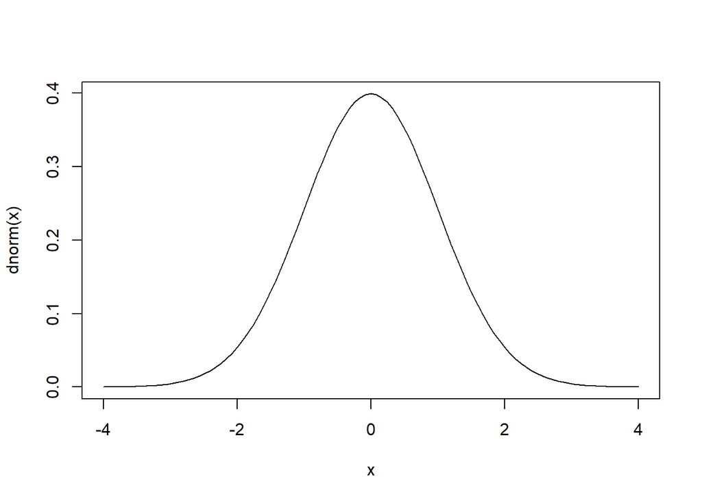

```r
curve(dnorm(x), xlim=c(-4,4))
```

## Código

R:

`stats: dnorm(x, mean, sd), pnorm(q, mean, sd), qnorm(p, mean, sd), rnorm(n, mean, sd)` donde `mean` es la media y `sd` es la desviación estándar de la normal $N(\mu, \sigma)$.

- `dnorm(x = posición en x, mean = media, sd = DS)`: Valor de densidad
- `pnorm(q = posición en x, mean = media, sd = DS)`: Función de distribución
- `qnorm(p = cuantil, mean = media, sd = DS)`: Función de cuantil
- `rnorm(n = cantidad de observaciones, mean = media, sd = DS)`: Valores aleatorios

Python:

`scipy.stats.norm`

`pdf(k, mu, scale), cdf(k, mu, scale), ppf(q, mu, scale), rvs(n, mu, scale)` donde `mu` es la media y `scale` es la desviación estándar de la normal $N(\mu, \sigma)$

- `pdf(k, mu, scale)`: Valor de densidad
- `cdf(k, mu, scale)`: Función de distribución (probabilidad acumulada)
- `ppf(q, mu, scale)`: Función de cuantil
- `rvs(n, mu, scale)`: Valores aleatorios

Si no se especifica otra $\mu$ o $\sigma$, se entiende que es la normal estándar.

## Estandarización

*Estandarización de una v.a. normal.* Si $X$ es una v.a. $N(\mu, \sigma)$ entonces

$$Z = \frac{X - \mu}{\sigma} \sim N(0,1)$$

Las probabilidades de una normal estándar $Z$ determinan las de cualquier $X$ de tipo $N(\mu, \sigma)$:

$$p(X \le x) = p\left( \frac{X - \mu}{\sigma} \le \frac{x - \mu}{\sigma} \right) = p(Z \le \frac{x - \mu}{\sigma})$$

$F_Z$ no tiene expresión conocida

Se puede calcular con cualquier programa, como por ejemplo R, o bien a mano usando las **tablas de la N(0,1)**

Con las tablas se pueden calcular tanto probabilidades como cuantiles.

## Función de distribución

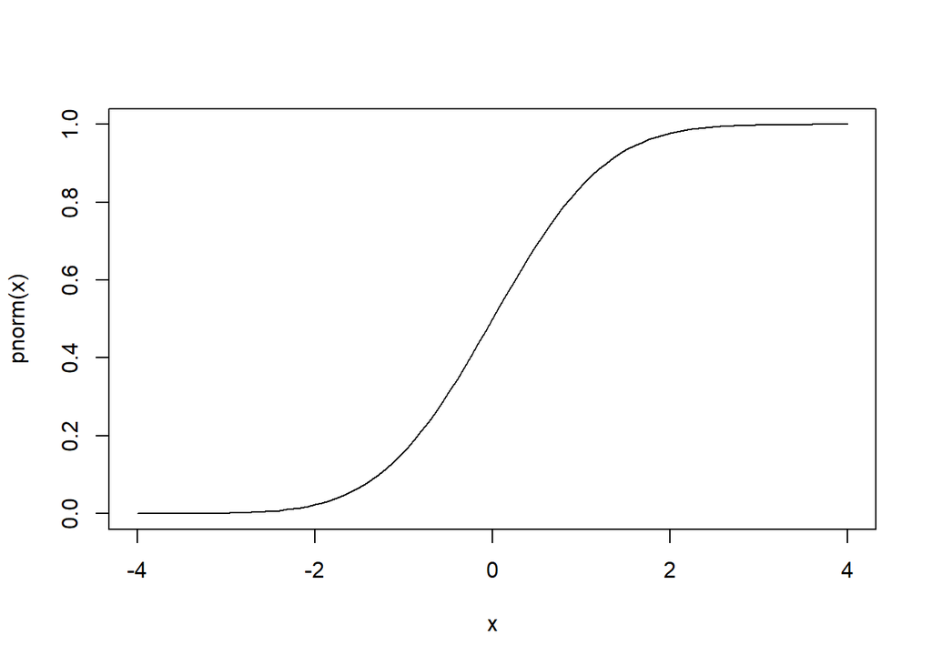

```r
curve(pnorm(x), xlim=c(-4,4))
```

En videojuegos, esta distribución se puede usar para definir la dificultad. xd

## Ejercicios

Dada una $X \sim N(0,1), calcular$

- $p(X \le 1.77)$

```r
pnorm(1.77)
```

```
## [1] 0.9616364
```

```r
pnorm(-1.77)
```

```
## [1] 0.03836357
```

- $p(-1.77 \le X \le 1.77)$

```r
pnorm(1.77) - pnorm(-1.77)
```

```
## [1] 0.9232729
```

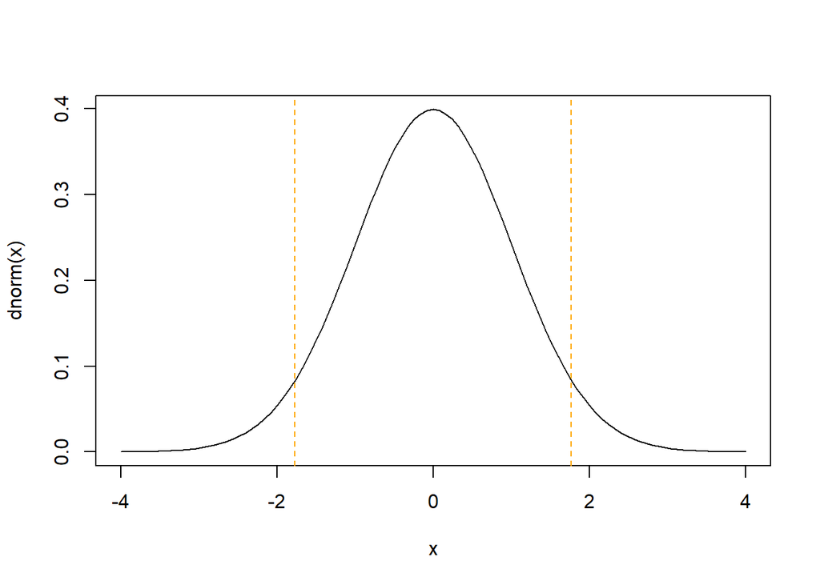

```r
curve(dnorm(x), xlim=c(-4,4))
abline(v = c(-1.77, 1.77), lty="dashed", col="orange")
```

- $p(X \ge 2.19)$

```r
pnorm(2.19, lower.tail = FALSE)
```

```
## [1] 0.01426212
```

- $p(X \le \alpha) = 0.6406$ ¿Cuánto vale $\alpha$ ?

```r
qnorm(0.6406)
```

```
## [1] 0.360063
```

```r
# Ya que
pnorm(0.360063)
```

```
## [1] 0.6406
```

- $p(X \ge \beta) = 0.9881$

```r
qnorm(0.9881, lower.tail = FALSE)
```

```
## [1] -2.260343
```

```r
# Ya que
pnorm(-2.260343, lower.tail = FALSE)
```

```
## [1] 0.9881
```

## ¿Cómo estandarizar variables aleatorias?

De media los pesos de 500 estudiantes de una clase universitaria es de 75 kg con una ds de 4 kg. Suponiendo que los pesos se distribuyen normalmente, hayar cuántos estudiantes pesan:

Si necesitara tablas, estandarizaría la v.a.

$$p(\frac{x - \mu}{\sigma} \le \frac{x - 75}{4})$$

- Entre 65 y 80 kg

```r
pnorm(80, mean = 75, sd = 4) - pnorm(65, mean = 75, sd = 4)
```

```
## [1] 0.8881406
```

- Más de 90 kg

```r
pnorm(90, mean = 75, sd = 4, lower.tail = FALSE)
```

```
## [1] 8.841729e-05
```

- 69 kg

```r
dnorm(69, mean = 75, sd = 4)
```

```
## [1] 0.0323794
```

- Menos de 70 kg

```r
pnorm(70, mean = 75, sd = 4)
```

```
## [1] 0.1056498
```

- 69 kg o más

```r
pnorm(69, mean = 75, sd = 4, lower.tail = FALSE)
```

```
## [1] 0.9331928
```